# R Notebook

```r
theme_set(minimal)
```

```
Error in theme_set(minimal) : object 'minimal' not found
```

```r
artists <- readr::read_csv('https://raw.githubusercontent.com/rfordatascience/tidytuesday/master/data/2022/2022-09-27/artists.csv')
```

# Okay, what are we looking at?

We have three categorical variables – 52 states, 5 races, and 13 types of artist. In theory these produce 3380 possible combinations, which is the number of observations in the data. Not all of these observations, though have all the data. Some have an NA in the `artists_n` and thus the share and quotient – 0, specifically. Another 756 have a known number of artists, but it is 0. In the majority of these cases this means that the share and quotient are thus NA, expect for two oddities:

```r
artists %>% filter(artists_n == 0 & !is.na(artists_share))
```

| state | race | type | all_workers_n | artists_n | artists_share | location_quotient |
| --- | --- | --- | --- | --- | --- | --- |
| West Virginia | Hispanic | Designers | 12005 | 0 | 0 | 0 |
| Puerto Rico | Asian | Photographers | 1335 | 0 | 0 | NA |

I think it makes sense to:

1. Remove entries that we just don’t have artists counts for

```r
artists <- artists %>% filter(!is.na(artists_n))
```

2. Replace NAs in share and quotient on entries with 0 artists with 0 Since we know what we have (0 artists) its fair to represent the share as 0 (0/all_workers_n), and we know the quotient must be 100% below the national labor force share.

```r
artists <- artists %>% mutate(artists_share = if_else(artists_n == 0,0, artists_share),location_quotient = if_else(artists_n == 0,0, location_quotient))
```

# Playing with plotting

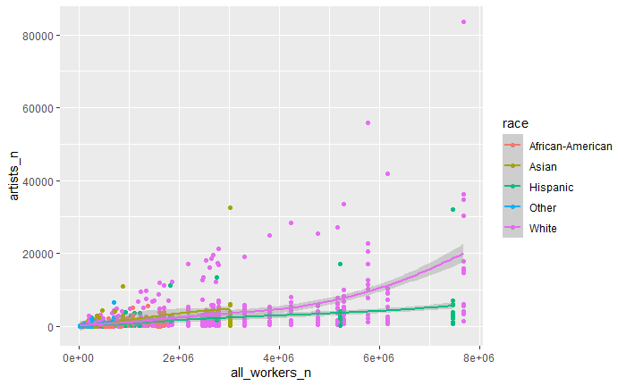

```r
ggplot(artists, aes(all_workers_n, artists_n, color=race)) + geom_point() + geom_smooth()
```

Makes since this doesn’t work, numbers would be different.

[figure not shown]

```r
ggplot(artists, aes(all_workers_n, artists_n, color=type))  + stat_smooth(geom='line', alpha=0.5, se=FALSE) +  geom_point() + facet_wrap(vars(race), scales="free")
```

Nice! Let’s remake some orderings.

```r
race_sort <- (artists %>% group_by(race) %>% summarize(a= mean(all_workers_n,na.rm=TRUE)) %>% arrange(-a))$race
type_sort <- (artists %>% group_by(type) %>% summarize(a= mean(artists_share,na.rm=TRUE)) %>% arrange(-a))$type
artists$race <- factor(artists$race,levels=race_sort,ordered=TRUE)
artists$type <- factor(artists$type,levels=type_sort,ordered=TRUE)
```

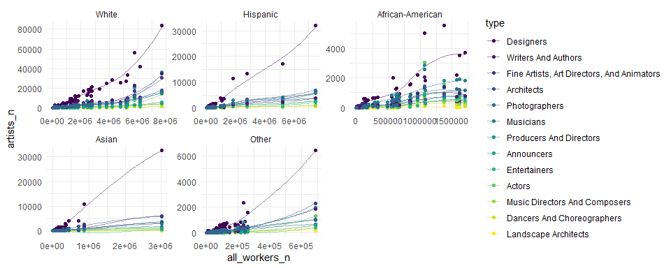

```r
ggplot(artists, aes(all_workers_n, artists_n, color=type))  + stat_smooth(geom='line', alpha=0.5, se=FALSE) +  geom_point() + facet_wrap(vars(race), scales="free")
```